# Exploratory Analysis of BC (Black Carbon) for mobile monitoring

Adithi R. Upadhya - ILK Labs

7/11/2020

# 1 Mobile Monitoring report

**The mobile monitoring campaign started in May 2019 with Diesel car, while the monitoring continued with CNG car from 09 July 2019.**

**All rides are included (CNG + Diesel).**

```r
all_data_summary <- all_data %>%
  dplyr::select(BC)
summ <- summary(all_data_summary)
summ <- data.frame(summ)
summ$Var1 <- NULL
names(summ) <- c("Parameter", "Stats")
summ
```

| Parameter | Stats |
| --- | --- |
| BC | Min. : 0.00 |
| BC | 1st Qu.: 11.40 |
| BC | Median : 24.01 |
| BC | Mean : 53.67 |
| BC | 3rd Qu.: 53.16 |
| BC | Max. :12837.72 |
| BC | NA's :101611 |

# 2 Data Availability of Black Carbon during mobile monitoring campaign (2019 - 2020)

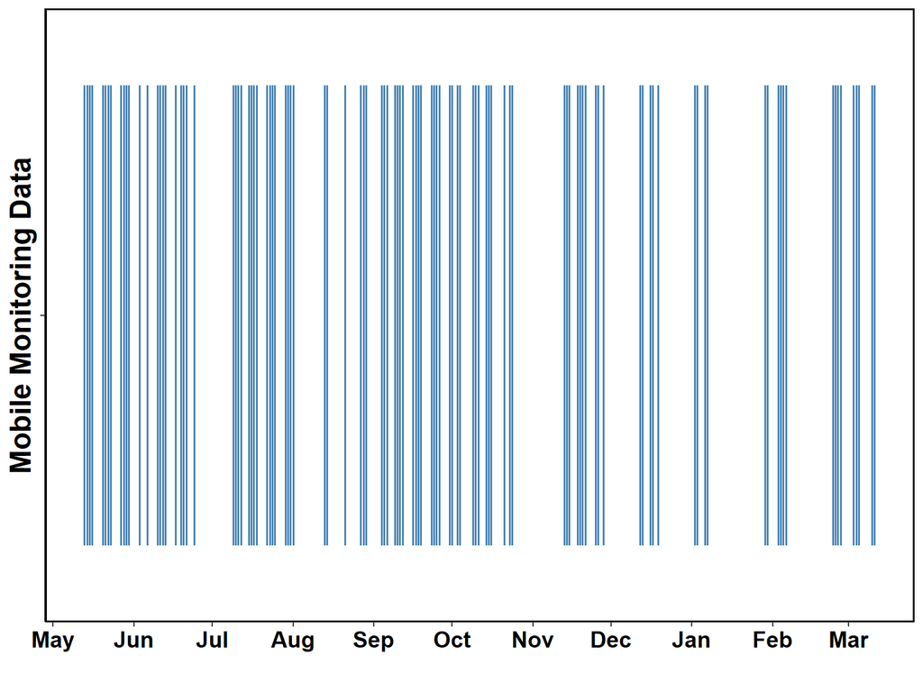

Fig 1: Data availability of BC for all rides

```r
all_data_BC <- all_data %>%
  dplyr::select(day, BC) %>%
        group_by(day) %>%
        summarise_all(funs(mean, sd, median, IQR), na.rm = TRUE)
names(all_data_BC) <- c("date", "BC_mean", "BC_sd", "BC_median", "BC_IQR")
no_na_df <- data.frame(all_data_BC$date, all_data_BC$BC_mean)
names(no_na_df) <- c("date", "BC")
no_na_df <- no_na_df[complete.cases(no_na_df), ]
no_na_df$Exp <- "Mobile Monitoring Data"
y <- ggplot(no_na_df, aes(x = date, y = Exp)) +
  geom_errorbarh(aes(xmax = date, xmin = date), size = 0.7, colour = "steelblue") +
  labs(x = "", y = "Mobile Monitoring Data") +
  scale_x_date(date_labels ="%b", date_breaks = "1 month") +
  theme_classic() +
  theme(legend.text = element_text(size = 14),
        plot.subtitle = element_text(size = 10, face = "bold"),
        axis.title = element_text(size = 18, colour = "black", face = "bold"),
        axis.text.y = element_blank(),
        axis.text.x = element_text(size = 14, colour = "black", face = "bold"),
        panel.border = element_rect(colour = "black", fill = NA, size = 1),
        legend.position = "none",
        strip.background = element_blank(), strip.text = element_blank())
y
```

# 3 Monthly Box Plot for Diesel and CNG Car

**The data used here is (loading corrected) BC which is aggregrated over snapped 30 m road segment and plotted for each month.**

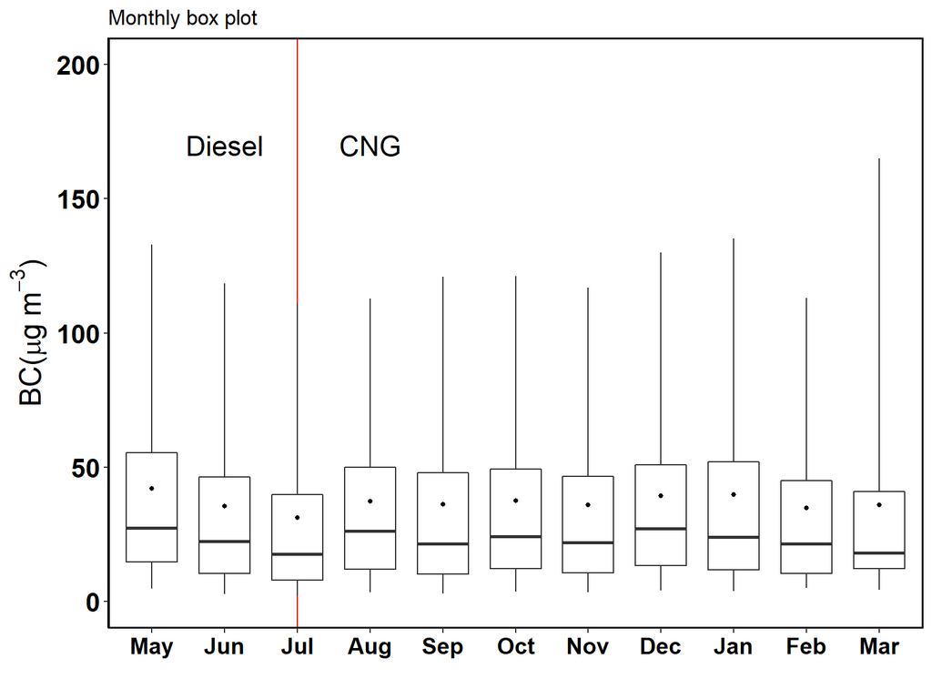

Fig 2: Monthly box plots of BC for all rides

```r
all_data$month <- format(all_data$date, "%Y-%m-01 01:00:00")
all_data$month <- as.POSIXct(all_data$month, format = '%Y-%m-%d %H:%M:%S',
                             tz = "Asia/Kolkata")
plot_box <- ggplot(all_data, aes(x = reorder(format(all_data$date, '%b'),
                                             all_data$date), y = BC)) +
  labs(title = "Monthly box plot", x = "", y = expression(paste(BC, "(", mu,
                                                                "g", ~ m^{-3}, ")"))) + geom_rect(data = all_data, aes(xmin = "Jul", xmax = "Jul", ymin = -Inf, ymax = Inf), colour = "red", fill = "red") +
  stat_summary(fun.data = f, geom ="boxplot", width = 0.7, size = 0.5) +
  stat_summary(fun.y = mean, geom = "point", size = 1) +
  scale_y_continuous(limits = c(0, 200)) + theme_classic() +
  theme(legend.text = element_text(size = 14),
        plot.subtitle = element_text(size = 10, face = "bold"),
        axis.title = element_text(size = 18, colour = "black", face = "bold"),
        axis.text = element_text(size = 16, colour = "black", face ="bold"),
        axis.text.x = element_text(size = 14, colour = "black", face = "bold"),
        panel.border = element_rect(colour = "black", fill = NA, size = 1)) + annotate(geom = "text", label = "Diesel", x = "Jun", y = 170, size = 6) + annotate(geom = "text", label = "CNG", x = "Aug", y = 170, size = 6)
plot_box
```

# 4 Daily Summary Statistics for Black Carbon

**Note:Transition from Diesel to CNG on 09 July 2019.**

```r
all_data_BC <- all_data %>%
  dplyr::select(day, Area, BC) %>%
        group_by(day, Area) %>%
        summarise_all(funs(mean, sd, median, IQR), na.rm = TRUE)
columns_of_interest <- 3:ncol(all_data_BC)
all_data_BC[ , columns_of_interest] <- sapply(X = all_data_BC[ , columns_of_interest], FUN = function(x) round(x, digits = 2))
names(all_data_BC) <- c("date", "Area", "BC_mean", "BC_sd", "BC_median", "BC_IQR")
all_data_BC
```

| date | Area | BC_mean | BC_sd | BC_median | BC_IQR |
| --- | --- | --- | --- | --- | --- |
| 2019-05-13 | MAL1 | 50.35 | 77.77 | 24.34 | 45.33 |
| 2019-05-14 | KAN | 50.03 | 73.53 | 27.38 | 42.71 |
| 2019-05-15 | CBD | 64.16 | 140.22 | 39.92 | 52.20 |
| 2019-05-16 | MAL2 | 52.85 | 68.02 | 31.08 | 48.03 |
| 2019-05-20 | CBD | 68.57 | 81.35 | 41.28 | 58.66 |
| 2019-05-21 | KAN | 89.68 | 150.96 | 42.92 | 92.21 |
| 2019-05-22 | MAL2 | 49.97 | 78.16 | 27.83 | 38.51 |
| 2019-05-23 | MAL1 | 38.37 | 50.36 | 20.84 | 30.15 |
| 2019-05-27 | KAN | 60.92 | 83.67 | 30.72 | 58.81 |
| 2019-05-28 | CBD | 91.24 | 113.71 | 56.99 | 72.72 |

[output cut: 99 more lines]

## 4.1 t-test to check for passes in CNG and Diesel.

**Daily mean calculated using the individual aggregated 30 m road segment data in each area. Here we used the daily mean of (loading corrected) BC to apply t-test for all the 4 (CBD + Kannur + Malleshwaram 1 + Malleshwaram 2) areas together.**

```r
all_data_BC_Dsl <- all_data_BC %>%
  dplyr::select(date, Area, BC_mean) %>%
  filter(date <= "2019-07-08")
names(all_data_BC_Dsl) <- c("date", "Area", "BC_Dsl")
all_data_BC_CNG <- all_data_BC %>%
  dplyr::select(date, Area, BC_mean) %>%
  filter(date >= "2019-07-09")
names(all_data_BC_CNG) <- c("date", "Area", "BC_CNG")
t_test <- t.test(all_data_BC_CNG$BC_CNG, all_data_BC_Dsl$BC_Dsl)
t_test
```

```
##
##  Welch Two Sample t-test
##
## data:  all_data_BC_CNG$BC_CNG and all_data_BC_Dsl$BC_Dsl
## t = 0.4634, df = 85.823, p-value = 0.6442
## alternative hypothesis: true difference in means is not equal to 0
## 95 percent confidence interval:
##  -8.179005 13.151076
## sample estimates:
## mean of x mean of y
##  54.16690  51.68087
```

**Here we used the daily mean of (loading corrected) BC to apply t-test for CBD CNG and Diesel data.**

```r
CBD_BC_Dsl <- all_data_BC %>%
  dplyr::select(date, Area, BC_mean) %>%
  filter(date <= "2019-07-08") %>%
  filter(Area == "CBD")
names(CBD_BC_Dsl) <- c("date", "Area", "BC_Dsl")
CBD_BC_CNG <- all_data_BC %>%
  dplyr::select(date, Area, BC_mean) %>%
  filter(date >= "2019-07-09") %>%
  filter(Area == "CBD")
names(CBD_BC_CNG) <- c("date", "Area", "BC_CNG")
t_test <- t.test(CBD_BC_CNG$BC_CNG, CBD_BC_Dsl$BC_Dsl)
t_test
```

```
##
##  Welch Two Sample t-test
##
## data:  CBD_BC_CNG$BC_CNG and CBD_BC_Dsl$BC_Dsl
## t = -0.34213, df = 15.98, p-value = 0.7367
## alternative hypothesis: true difference in means is not equal to 0
## 95 percent confidence interval:
##  -20.36701  14.70701
## sample estimates:
## mean of x mean of y
##  61.80667  64.63667
```

**Here we used the daily mean of (loading corrected) BC to apply t-test for Kannuru CNG and Diesel data.**

```r
KAN_BC_Dsl <- all_data_BC %>%
  dplyr::select(date, Area, BC_mean) %>%
  filter(date <= "2019-07-08") %>%
  filter(Area == "KAN")
names(KAN_BC_Dsl) <- c("date", "Area", "BC_Dsl")
KAN_BC_CNG <- all_data_BC %>%
  dplyr::select(date, Area, BC_mean) %>%
  filter(date >= "2019-07-09") %>%
  filter(Area == "KAN")
names(KAN_BC_CNG) <- c("date", "Area", "BC_CNG")
t_test <- t.test(KAN_BC_CNG$BC_CNG, KAN_BC_Dsl$BC_Dsl)
t_test
```

```
##
##  Welch Two Sample t-test
##
## data:  KAN_BC_CNG$BC_CNG and KAN_BC_Dsl$BC_Dsl
## t = 1.3423, df = 10.382, p-value = 0.2081
## alternative hypothesis: true difference in means is not equal to 0
## 95 percent confidence interval:
##  -6.306311 25.658691
## sample estimates:
## mean of x mean of y
##  66.13619  56.46000
```

**Here we used the daily mean of (loading corrected) BC to apply t-test for Malleshwaram 1 CNG and Diesel data.**

```r
MAL1_BC_Dsl <- all_data_BC %>%
  dplyr::select(date, Area, BC_mean) %>%
  filter(date <= "2019-07-08") %>%
  filter(Area == "MAL1")
names(MAL1_BC_Dsl) <- c("date", "Area", "BC_Dsl")
MAL1_BC_CNG <- all_data_BC %>%
  dplyr::select(date, Area, BC_mean) %>%
  filter(date >= "2019-07-09") %>%
  filter(Area == "MAL1")
names(MAL1_BC_CNG) <- c("date", "Area", "BC_CNG")
t_test <- t.test(MAL1_BC_CNG$BC_CNG, MAL1_BC_Dsl$BC_Dsl)
t_test
```

```
##
##  Welch Two Sample t-test
##
## data:  MAL1_BC_CNG$BC_CNG and MAL1_BC_Dsl$BC_Dsl
## t = 1.2411, df = 23.371, p-value = 0.2269
## alternative hypothesis: true difference in means is not equal to 0
## 95 percent confidence interval:
##  -11.27563  45.17326
## sample estimates:
## mean of x mean of y
##  58.88682  41.93800
```

**Here we used the daily mean of (loading corrected) BC to apply t-test for Malleshwaram 2 CNG and Diesel data.**

```r
MAL2_BC_Dsl <- all_data_BC %>%
  dplyr::select(date, Area, BC_mean) %>%
  filter(date <= "2019-07-08") %>%
  filter(Area == "MAL2")
names(MAL2_BC_Dsl) <- c("date", "Area", "BC_Dsl")
MAL2_BC_CNG <- all_data_BC %>%
  dplyr::select(date, Area, BC_mean) %>%
  filter(date >= "2019-07-09") %>%
  filter(Area == "MAL2")
names(MAL2_BC_CNG) <- c("date", "Area", "BC_CNG")
t_test <- t.test(MAL2_BC_CNG$BC_CNG, MAL2_BC_Dsl$BC_Dsl)
t_test
```

```
##
##  Welch Two Sample t-test
##
## data:  MAL2_BC_CNG$BC_CNG and MAL2_BC_Dsl$BC_Dsl
## t = -1.9545, df = 5.1753, p-value = 0.1061
## alternative hypothesis: true difference in means is not equal to 0
## 95 percent confidence interval:
##  -24.861797   3.260797
## sample estimates:
## mean of x mean of y
##   28.3855   39.1860
```

# 5 Monthly Diurnal variation of BC using BCc channel of AE33

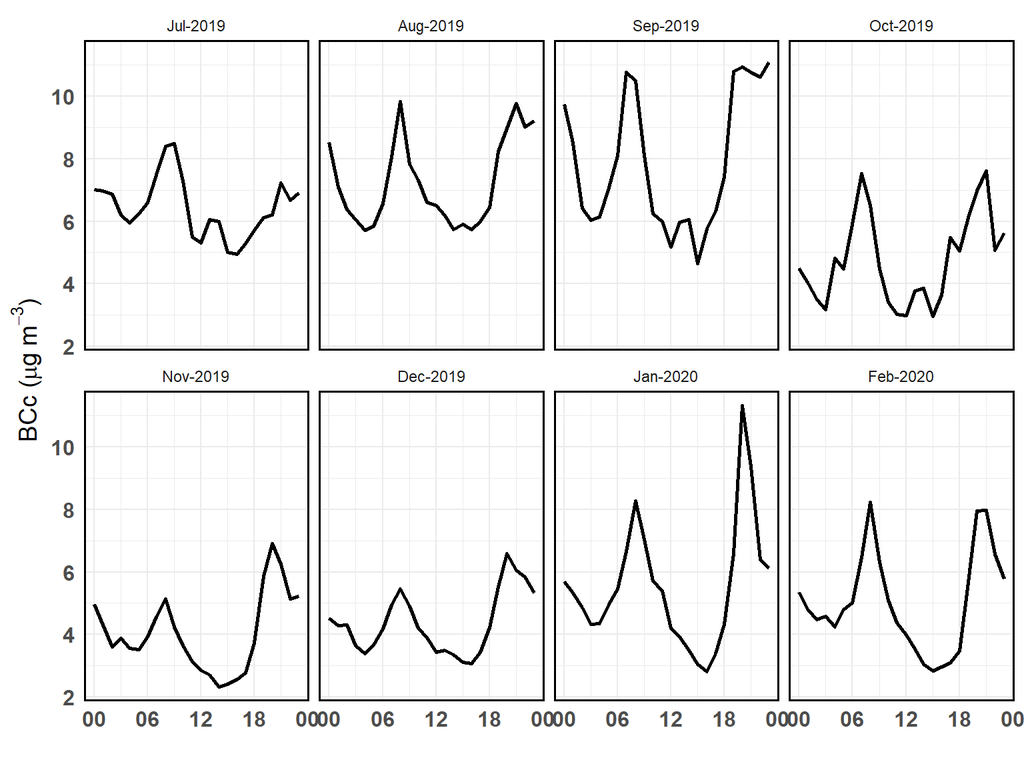

Fig 3: Monthly diurnal variation from AE33

```r
Final_cq <- Final_c
Final_cq$size_f <- factor(Final_cq$month, levels = c('Jul-2019', 'Aug-2019', 'Sep-2019', 'Oct-2019', 'Nov-2019', 'Dec-2019', 'Jan-2020', 'Feb-2020'))
min_m <- data.frame(Final_cq)
min_m$hour <- format(as.POSIXct(min_m$hour, format = "%H"), format = "%H:%M:%S")
min_m$hour <- as.POSIXct(paste0("2016-09-23 ", min_m$hour), tz = "Asia/Kolkata")
min_m$mean_AE33_cstep <- as.numeric(as.character(min_m$mean_AE33_cstep))
ae33_line <- ggplot(data = min_m, aes(hour, mean_AE33_cstep)) +
  geom_line(size =  0.9) + theme_minimal() +
  scale_x_datetime(date_labels = "%H") + facet_wrap(~ size_f, nrow = 2) +
  labs(y = expression(paste(BCc, " (", mu, "g", ~m^{-3}, ")")), x = "") + scale_y_continuous() +
  theme(legend.position = "bottom",
        legend.text = element_text(size = 14),
        plot.title = element_text(size = 12, face = "bold"),
        plot.subtitle = element_text(size = 10, face = "bold"),
        axis.title = element_text(size=14),
        axis.text = element_text(size = 12, face = "bold"),
        panel.border = element_rect(colour = "black", fill = NA, size = 1))
ae33_line
```